[figure not shown]

## **1. Đồ thị Euler**

## **2. Đồ thị Hamilton**

# 1. Đồ thị Euler

**Định nghĩa:**

Đường đi Euler: là đường đi của đồ thị đi qua tất cả các cạnh của đồ thị $G$, mỗi cạnh chỉ đi qua một lần. Đồ thị có đường đi Euler được gọi là đồ thị nửa Euler.

Chu trình Euler: là chu trình của đồ thị đi qua tất cả các cạnh của đồ thị $G$, mỗi cạnh chỉ đi qua một lần. Đồ thị có chu trình Euler được gọi là đồ thị Euler.

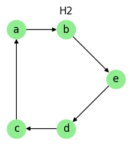

```python
import matplotlib.pyplot as plt
import networkx as nx

# Tạo đồ thị vô hướng
G = nx.DiGraph()

# Danh sách các cạnh
#edges = [("a", "b"),("a", "c"),("c", "d"),("c", "k"),("d", "g"),("b", "k"),("b", "s"),("k", "e"),("s", "e"),("c", "b"),("c", "g")]
edges = [("a", "b"),("c", "a"),("d", "c"),("b", "e"),("e", "d")]
pos = {"a": (0, 0.25), "c": (0, 0), "b": (0.25, 0.25), "d": (0.25,0), "e": (0.5,0.125)}
#pos = {"a": (0, 0.5), "b": (0.5, 0.5), "c": (1, 0.5), "d": (0, 0), "f": (1, 0)}
#G.add_nodes_from(["f"])
# Thêm các cạnh vào đồ thị
G.add_edges_from(edges)

# Vẽ đồ thị
plt.figure(figsize=(2, 2))

# Vẽ graph
nx.draw(G, pos, with_labels=True, node_color="lightgreen", node_size=500, font_size=12)
plt.title("H2")
plt.show()
```

**Nhận xét:** Nếu $G$ là đồ thị Euler thì $G$ là đồ thị nửa Euler.

**Định lí:**

Đồ thị vô hướng liên thông $G=(V,E)$ là đồ thị Euler khi và chỉ khi mọi đỉnh của $G$ đều có bậc chẵn.

Đồ thị có hướng liên thông yếu $G=(V,E)$ là đồ thị Euler khi và chỉ khi $\text{deg}^-(v)=\text{deg}^+(v)$ với mọi $v\in V$ (khi đó đồ thị là liên thông mạnh).

**Hệ quả:**

Đồ thị vô hướng $G=(V,E)$ là nửa Euler khi và chỉ khi có đúng hai đỉnh bậc lẻ.

Đồ thị có hướng liên thông yếu $G=(V,E)$ là đồ thị nửa Euler khi và chỉ khi tồn tại đúng 2 đỉnh $u,v\in V$ sao cho $$\text{deg}^+(u)-\text{deg}^-(u)=\text{deg}^-(v)-\text{deg}^+(v)=1,$$các đỉnh còn lại có $\text{deg}^-=\text{deg}^+$. Đường đi Euler sẽ xuất phát tại đỉnh $u$ và kết thúc tại đỉnh $v$.

**Thuật toán tìm chu trình Euler, đường đi:**

- B1: Kiểm tra tính liên thông của đồ thị bằng BFS(s) hoặc DFS(s)
- B2: Tính số bậc của các đỉnh, nếu gồm toàn đỉnh bậc chẵn thì tìm chu trình Euler xuất phát tại đỉnh bất kì, nếu có 2 đỉnh bậc lẻ thì tìm đường đi Euler xuất phát từ một trong hai đỉnh bậc lẻ
- B3: Tạo mảng CE để ghi đường đi và một stack để xếp các đỉnh ta sẽ xét. Xếp vào đó một đỉnh $u$ nào đó của đồ thị, nghĩa là đỉnh $u$ sẽ được xét đầu tiên.
- B4: Xét đỉnh trên cùng của ngăn xếp, giả sử là đỉnh $v$:
  - Nếu $v$ là đỉnh cô lập thì lấy $v$ khỏi ngăn xếp và đưa vào CE;
  - Nếu $v$ liên thông với $x$ thì xếp $x$ vào ngăn xếp và xoá cạnh $(v, x)$;
- B5: Quay lại bước 2 cho tới khi ngăn xếp rỗng.
- B6: Kết quả chu trình Euler (đường đi Euler) được chứa trong CE theo thứ tự ngược lại!

**Hàm kiểm tra tính liên thông của đồ thị (dùng BFS hoặc DFS)**

**Hàm tính số bậc của mỗi đỉnh**

**Euler_walk(graph, start)**

- Khởi tạo: 𝑠𝑡𝑎𝑐𝑘: = ∅; 𝑊 = ∅ // W: mảng CE
- 𝑠𝑡𝑎𝑐𝑘 ⇐ 𝑢 // Đưa đỉnh xuất phát 𝑢 vào stack  
  **While** 𝑠𝑡𝑎𝑐𝑘 ≠ ∅
  - 𝑥: = 𝑡𝑜𝑝(𝑠𝑡𝑎𝑐𝑘) (*Phần tử đầu stack*)
  - **If** 𝑘𝑒(𝑥) ≠ ∅
    - 𝑦: = 𝑡𝑜𝑝(𝑘𝑒(𝑥)); 𝑠𝑡𝑎𝑐𝑘 ⇐ 𝑦 // Nạp y vào stack
    - 𝑘𝑒(𝑥): = 𝑘𝑒(𝑥) − {𝑦}
    - 𝑘𝑒(𝑦): = 𝑘𝑒(𝑦) − {𝑥} // Loại bỏ cạnh 𝑥𝑦 khỏi 𝐺
  - **Else** // 𝑥 là đỉnh cô lập
    - 𝑥 ⇐ 𝑠𝑡𝑎𝑐𝑘 // Loại 𝑥 khỏi stack
    - 𝑊 ⇐ 𝑥 // Nạp 𝑥 vào W

**Main program**

- Nhập: G, đỉnh xuất phát (s)
- euler_walk(G, s)

**Chú ý:** Thủ tục **Euler_walk** cũng được áp dụng để xác định đường đi Euler trên đồ thị nửa Euler, nhưng đỉnh xuất phát phải là một đỉnh lẻ.

```python
def euler_walk(graph, start):
    stack = []  # Ngăn xếp để lưu các đỉnh
    CE = []  # Chu trình hoặc hành trình Euler
    stack.append(start)# Khởi tạo ngăn xếp với đỉnh bắt đầu
    while stack:
        x = stack[-1]  # Lấy đỉnh đầu ngăn xếp
        if graph[x]:  # Nếu x còn đỉnh kề
            y = graph[x].pop()  # Lấy một đỉnh kề
            stack.append(y)  # Đưa y vào ngăn xếp
            graph[y].remove(x) # Loại bỏ cạnh x-y khỏi cả x và y
        else:
            CE.append(stack.pop()) # x là đỉnh cô lập; loại bỏ khỏi ngăn xếp và thêm vào chu trình
    return CE[::-1]
graph = {'a': ['b', 'e'],
         'b': ['a', 'e'],
         'c': ['d', 'e'],
         'd': ['c', 'e'],
         'e': ['a', 'b', 'c', 'd']}
start_vertex = 'a'
CE = euler_walk(graph, start_vertex)
print("Chu trình Euler:", CE)
```

```
Chu trình Euler: ['a', 'e', 'd', 'c', 'e', 'b', 'a']
```

```python
# cho đồ thị vô hướng
def is_connected(graph, start):
    visited = [start]
    Q = [start]  # Khởi tạo hàng đợi với đỉnh start
    while Q:
        u = Q.pop()  # Lấy đỉnh u ra khỏi hàng đợi
        for v in graph[u]:   # Duyệt các đỉnh kề với u
            if v not in visited:  # Nếu v chưa được thăm
                visited.append(v)
                Q.append(v)       # Đưa v vào hàng đợi
    return len(visited) == len(graph)

def euler_path_or_circuit(graph,start):
    stack = []  # Ngăn xếp để lưu các đỉnh # Bước 3: Tạo mảng CE và ngăn xếp
    CE = []  # Chu trình hoặc hành trình Euler
    stack.append(start)  # Khởi tạo ngăn xếp với đỉnh bắt đầu
    while stack:
        x = stack[-1]  # Lấy đỉnh đầu ngăn xếp
        if graph[x]:  # Nếu x còn đỉnh kề
            y = graph[x].pop()  # Lấy một đỉnh kề
            stack.append(y)  # Đưa y vào ngăn xếp
            graph[y].remove(x)  # Loại bỏ cạnh x-y khỏi cả x và y
        else:
            CE.append(stack.pop())  # x là đỉnh cô lập; loại bỏ khỏi ngăn xếp và thêm vào chu trình
    CE.reverse()# Đảo ngược chu trình để có thứ tự đúng
    return CE

# graph = {'a': ['b', 'e'],
#          'b': ['a', 'e'],
#          'c': ['d', 'e'],
#          'd': ['c', 'e'],
#          'e': ['a', 'b', 'c', 'd']}# Ví dụ đồ thị có chu trình
graph = {'a': ['b', 'e'],
         'b': ['a', 'e'],
         'c': ['d', 'e'],
         'd': ['c'],
         'e': ['a', 'b', 'c']}# Ví dụ đồ thị có đường đi
start = list(graph.keys())[0]  # Bước 1: Kiểm tra tính liên thông
if not is_connected(graph, start):
    print("Đồ thị không liên thông, không thể tìm đường đi/chu trình Euler.")
odd_degree_vertices = [v for v in graph if len(graph[v]) % 2 != 0]  # Bước 2: Tính bậc của các đỉnh
if len(odd_degree_vertices) > 2:  # Kiểm tra số lượng đỉnh bậc lẻ
    print("Đồ thị có nhiều hơn 2 đỉnh bậc lẻ, không thể tìm đường đi/chu trình Euler.")
elif len(odd_degree_vertices) == 2:
    start = odd_degree_vertices[0]  # Bắt đầu từ một đỉnh bậc lẻ
    print("Đồ thị có đường đi Euler. Bắt đầu từ đỉnh:", start, "là", euler_path_or_circuit(graph,start))
elif len(odd_degree_vertices) == 0:
    start = list(graph.keys())[0]  # Bắt đầu từ bất kỳ đỉnh nào nếu tất cả bậc đều chẵn
    print("Đồ thị có chu trình Euler là:",euler_path_or_circuit(graph,start))
else:
    print("Đồ thị không hợp lệ cho đường đi/chu trình Euler.")
```

```
Đồ thị có đường đi Euler. Bắt đầu từ đỉnh: d là ['d', 'c', 'e', 'b', 'a', 'e']
```

- Chỉ có 3 trường hợp: số đỉnh bậc lẻ là 0 (toàn bậc chẵn), 2 và lớn hơn 2. Nếu ko rơi vào 2 trường hợp sau thì chắc chắn là trường hợp đầu (=0), khi đó xuất phát từ đỉnh nào cũng đc

```python
# cho đồ thị có hướng
def dfs(v, visited, graph):
    visited.append(v)
    for neighbor in graph[v]:
        if neighbor not in visited:
            dfs(neighbor, visited, graph)

def to_undirected(graph):  # Chuyển đồ thị có hướng thành đồ thị vô hướng
    undirected_graph = {v: [] for v in graph}
    for u in graph:
        for v in graph[u]:
            if v not in undirected_graph[u]:
                undirected_graph[u].append(v)
            if u not in undirected_graph[v]:
                undirected_graph[v].append(u)
    return undirected_graph

def is_weakly_connected(graph):
    visited = []
    start = list(graph.keys())[0]
    undirected_graph = to_undirected(graph) # Chuyển đồ thị có hướng thành vô hướng
    dfs(start, visited, undirected_graph) # Thực hiện DFS trên đồ thị vô hướng
    return len(visited) == len(graph) # Kiểm tra xem tất cả các đỉnh đã được thăm

def euler_path_or_circuit(graph, start, end=None):
    stack = []  # Ngăn xếp để lưu các đỉnh
    CE = []  # Chu trình hoặc hành trình Euler
    stack.append(start)  # Khởi tạo ngăn xếp với đỉnh bắt đầu
    while stack:
        x = stack[-1]  # Lấy đỉnh đầu ngăn xếp
        if graph[x]:  # Nếu x còn đỉnh kề
            y = graph[x].pop()  # Lấy một đỉnh kề
            stack.append(y)  # Đưa y vào ngăn xếp
        else:
            CE.append(stack.pop())  # x là đỉnh cô lập; loại bỏ khỏi ngăn xếp và thêm vào chu trình
    CE.reverse()  # Đảo ngược chu trình để có thứ tự đúng
    if end:
        print("Đồ thị có đường đi Euler:", CE)
    else:
        print("Đồ thị có chu trình Euler:", CE)

# Ví dụ sử dụng
# graph = {
#     'a': ['b'],
#     'b': ['c','e'],
#     'c': ['a', 'd'],
#     'd': ['e'],
#     'e': ['b','c']
# }  # Đồ thị cho chu trình Euler
graph = {
    'a': [],
    'b': ['c', 'd'],
    'c': ['d'],
    'd': ['a', 'e'],
    'e': ['b']
}  # Đồ thị cho đường đi Euler
in_degree = {v: 0 for v in graph}
out_degree = {v: 0 for v in graph}
for u in graph:
    out_degree[u] += len(graph[u])
    for v in graph[u]:
        in_degree[v] += 1
if not is_weakly_connected(graph):  # Kiểm tra tính liên thông yếu
    print("Đồ thị không liên thông yếu, không thể là đồ thị Euler hoặc nửa Euler.")
else:
    start, end = None, None  # Kiểm tra điều kiện Euler hoặc nửa Euler
    for v in graph:
        if out_degree[v] - in_degree[v] == 1:
            if start is None:
                start = v
            else:
                print("Đồ thị không hợp lệ cho đường đi Euler (quá nhiều đỉnh bậc ra lớn hơn bậc vào).")
                break
        elif in_degree[v] - out_degree[v] == 1:
            if end is None:
                end = v
            else:
                print("Đồ thị không hợp lệ cho đường đi Euler (quá nhiều đỉnh bậc vào lớn hơn bậc ra).")
                break
        elif in_degree[v] != out_degree[v]:
            print("Đồ thị không hợp lệ cho đường đi/chu trình Euler.")
            break
    if start is None: # Nếu là chu trình Euler, chọn đỉnh bất kỳ làm điểm bắt đầu
        start = list(graph.keys())[0]
    euler_path_or_circuit(graph, start, end) # Gọi hàm để tìm chu trình hoặc đường đi Euler
```

```
Đồ thị có đường đi Euler: ['b', 'd', 'e', 'b', 'c', 'd', 'a']
```

# 2. Đồ thị Hamilton

**Định nghĩa:**

Đường đi Hamilton: là đường đi đơn đi qua tất cả các đỉnh của đồ thị $G$. Đồ thị có đường đi Hamilton được gọi là đồ thị nửa Hamilton.

Chu trình Hamilton: là chu trình đơn đi qua tất cả các đỉnh của đồ thị $G$. Đồ thị có chu trình Hamilton được gọi là đồ thị Hamilton.

**Nhận xét:** Nếu $G$ là đồ thị Hamilton thì $G$ là đồ thị nửa Hamilton.

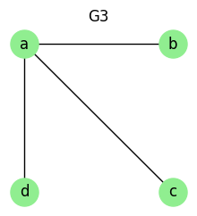

```python
import matplotlib.pyplot as plt
import networkx as nx

# Tạo đồ thị vô hướng
G = nx.Graph()

# Danh sách các cạnh
#edges = [("a", "b"),("a", "c"),("c", "d"),("c", "k"),("d", "g"),("b", "k"),("b", "s"),("k", "e"),("s", "e"),("c", "b"),("c", "g")]
edges = [("a", "b"),("c", "a"),("a", "d")]
pos = {"a": (0, 0.25), "d": (0, 0), "b": (0.25, 0.25), "c": (0.25,0)}
#pos = {"a": (0, 0.5), "b": (0.5, 0.5), "c": (1, 0.5), "d": (0, 0), "f": (1, 0)}
#G.add_nodes_from(["f"])
# Thêm các cạnh vào đồ thị
G.add_edges_from(edges)

# Vẽ đồ thị
plt.figure(figsize=(2, 2))

# Vẽ graph
nx.draw(G, pos, with_labels=True, node_color="lightgreen", node_size=500, font_size=12)
plt.title("G3")
plt.show()
```

**Định lí:** Giả sử $G$ là đồ thị Hamilton. Khi đó,

mọi đỉnh của nó phải có bậc lớn hơn hoặc bằng 2

một đỉnh bậc 2 thì hai cạnh của nó phải nằm trên một chu trình Hamilton.

một đỉnh có bậc lớn hơn 2 và có hai cạnh của nó nằm trên một chu trình Hamilton thì các cạnh còn lại của nó không nằm trên chu trình Hamilton đó.

**Thuật toán:** **(tìm chu trình Hamilton)**

- B1: Xuất phát từ một đỉnh $v_0$ bất kỳ trong đồ thị.
- B2: Từ $v_0$, lần lượt chọn các cạnh $(v_0,v_1)$, $(v_1,v_2)$,... sao cho:
  - Đỉnh $v_i$ chưa nằm trong đường đi hiện tại.
  - Cạnh $(v_{i-1},v_i)\in E$
- B3: Kiểm tra điều kiện hoàn thành: nếu đường đi đã bao gồm tất cả các đỉnh và có cạnh nối từ đỉnh cuối cùng trở về $v_0$ thì đã tìm được một chu trình Hamilton.
- B4: Nếu không thể mở rộng đường đi, quay lại bước trước đó và thử lựa chọn khác.
- B5: Thực hiện các bước trên cho đến khi không còn chu trình Hamilton nào có thể được tìm thấy.

**Main program**

- Khởi tạo: G, `X = [None] * (n + 1)`, `visited = {v: False for v in G}`, `cycles = []` //Danh sách chứa các chu trình Hamilton tìm được
- X[1] = v0 // v0 là một đỉnh nào đó của đồ thị
- visited[v0] = True
- Hamilton(1)

```python
# thuật toán quay lui để liệt kê chu trình Hamilton
def Hamilton(k):
    for y in G[X[k - 1]]:  # Duyệt các đỉnh kề của X[k-1]
        if k == n and y == v0:  # Khi đã đi qua n đỉnh và có cạnh về đỉnh bắt đầu
            cycles.append(X[0:] + [v0])  # Lưu chu trình Hamilton
        elif not visited[y]:  # Nếu đỉnh y chưa được xét
            X[k] = y  # Thêm đỉnh y vào vị trí k
            visited[y] = True  # Đánh dấu đỉnh y đã xét
            Hamilton(k + 1)  # Đệ quy để tiếp tục phát triển chu trình
            visited[y] = False  # Quay lui, bỏ đánh dấu đỉnh y
    return cycles

G = {
    'A': ['B', 'C'],
    'B': ['A', 'C', 'D'],
    'C': ['A', 'B', 'D'],
    'D': ['B', 'C']
}
n = len(G)
X = [None] * n
visited = {v: False for v in G}
cycles = []
v0 = 'A'  # Đỉnh bắt đầu
visited[v0] = True  # Đánh dấu đỉnh v0 đã được xét
X[0] = v0  # Đỉnh bắt đầu của chu trình
result = Hamilton(1)
print("Các chu trình Hamilton tìm được:")
for cycle in result:
    print(" -> ".join(cycle))
```

```
Các chu trình Hamilton tìm được:
A -> B -> D -> C -> A
A -> C -> D -> B -> A
```

```python
#Đường đi Hamilton
def Hamilton(k):
    for y in G[X[k - 1]]:  # Duyệt các đỉnh kề của X[k-1]
        if not visited[y]:  # Nếu đỉnh y chưa được xét
            X[k] = y  # Thêm đỉnh y vào vị trí k
            visited[y] = True  # Đánh dấu đỉnh y đã xét
            if k == n:  # Khi đã đi qua đủ n đỉnh
                paths.append(X[1:k + 1])  # Lưu đường đi Hamilton
            else:
                Hamilton(k + 1)  # Đệ quy để tiếp tục phát triển đường đi
            visited[y] = False  # Quay lui, bỏ đánh dấu đỉnh y
    return paths

# Chương trình chính
# Đồ thị biểu diễn bằng danh sách kề
G = {
    'A': ['B', 'C'],
    'B': ['A', 'C', 'D'],
    'C': ['A', 'B', 'D'],
    'D': ['B', 'C']
}

n = len(G)
X = [None] * (n + 1)  # Lưu đường đi hiện tại
visited = {v: False for v in G}  # Đánh dấu trạng thái các đỉnh
paths = []  # Lưu các đường đi Hamilton tìm được

v0 = 'A'  # Đỉnh bắt đầu
visited[v0] = True  # Đánh dấu đỉnh v0 đã được xét
X[1] = v0  # Đỉnh bắt đầu của đường đi

result = Hamilton(1)
print("Các đường đi Hamilton tìm được:")
for path in result:
    print(" -> ".join(path))  # In các đường đi
```

[output not shown]

```python
# tổng quát cho cả đường đi lẫn chu trình
def Hamilton(k):
    for y in G[X[k - 1]]:  # Duyệt các đỉnh kề của X[k-1]
        if k == n:  # Đã đi qua đủ n đỉnh
            if y == v0:  # Nếu có cạnh quay lại đỉnh ban đầu -> chu trình
                results['cycles'].append(X[:k] + [v0])  # Lưu chu trình
        elif not visited[y]:  # Nếu đỉnh y chưa được xét
            X[k] = y
            visited[y] = True
            Hamilton(k + 1)  # Đệ quy tìm tiếp
            visited[y] = False  # Quay lui
    if k == n and not results['cycles'] and y != v0:  # Chỉ lưu đường đi nếu không có chu trình nào được tìm thấy
        results['paths'].append(X[:k])
    return results

# G = {'A': ['B', 'C'],
#      'B': ['A', 'C', 'D'],
#      'C': ['A', 'B', 'D'],
#      'D': ['B', 'C']} # ví dụ về chu trình
G = {'A': ['B'],
     'B': ['A', 'C', 'D'],
     'C': ['B', 'D'],
     'D': ['B', 'C']} # ví dụ về đường đi
n = len(G)
X = [None] * n  # Lưu đường đi hiện tại
visited = {v: False for v in G}  # Đánh dấu trạng thái các đỉnh
results = {'cycles': [], 'paths': []}  # Lưu kết quả
v0 = 'A'  # Đỉnh bắt đầu
visited[v0] = True  # Đánh dấu đỉnh bắt đầu
X[0] = v0  # Đỉnh đầu tiên trong đường đi
Hamilton(1)
# In kết quả
if results['cycles']:
    print("Các chu trình Hamilton tìm được:")
    for cycle in results['cycles']:
        print(" -> ".join(cycle))
else:
    print("\nCác đường đi Hamilton tìm được:")
    for path in results['paths']:
        print(" -> ".join(path))
```

```
Các đường đi Hamilton tìm được:
A -> B -> C -> D
A -> B -> D -> C
```